# Practica 3

Garcia Giron A

7/11/2020

Instalamos librerias

```r
library(corrplot)
library(tidyverse)
library(caret)
library(magrittr)
library(knitr)
library(rsample)
library(PerformanceAnalytics)
library(leaps)
library(skimr)
library(bestglm)
library(gam)
library(glmnet)
library(ggcorrplot)
library(ISLR)
library(readr)
library(janitor)
library(imputeTS)
```

Cargamos y limpiamos la Data

```r
data_pisa <- read_csv("../data/pisasci2006.csv")
#limpiamos de posibles simbolos adversos
data_pisa %<>% clean_names()
colnames(data_pisa)
```

```
##  [1] "country"  "overall"  "issues"   "explain"  "evidence" "interest"
##  [7] "support"  "income"   "health"   "edu"      "hdi"
```

```r
data_pisa <- na_mean(data_pisa)
```

Summarize de los datos, un Skim es completo.

```r
skim(data_pisa)
```

Data summary

| Name | data_pisa |
| --- | --- |
| Number of rows | 65 |
| Number of columns | 11 |
| _______________________ |  |
| Column type frequency: |  |
| character | 1 |
| numeric | 10 |
| ________________________ |  |
| Group variables | None |

**Variable type: character**

| skim_variable | n_missing | complete_rate | min | max | empty | n_unique | whitespace |
| --- | --- | --- | --- | --- | --- | --- | --- |
| country | 0 | 1 | 4 | 24 | 0 | 65 | 0 |

**Variable type: numeric**

| skim_variable | n_missing | complete_rate | mean | sd | p0 | p25 | p50 | p75 | p100 | hist |
| --- | --- | --- | --- | --- | --- | --- | --- | --- | --- | --- |
| overall | 0 | 1 | 473.14 | 51.06 | 322.00 | 436.00 | 487.00 | 511.00 | 563.00 | ▁▂▂▇▃ |
| issues | 0 | 1 | 469.91 | 50.44 | 321.00 | 431.00 | 483.00 | 509.00 | 555.00 | ▁▂▂▇▅ |
| explain | 0 | 1 | 475.02 | 50.53 | 334.00 | 441.00 | 483.00 | 516.00 | 566.00 | ▁▂▂▇▃ |
| evidence | 0 | 1 | 469.81 | 57.75 | 288.00 | 429.00 | 481.00 | 512.00 | 567.00 | ▁▂▂▇▅ |
| interest | 0 | 1 | 528.16 | 46.62 | 448.00 | 503.00 | 528.16 | 549.00 | 644.00 | ▆▇▇▃▂ |
| support | 0 | 1 | 512.18 | 24.40 | 447.00 | 497.00 | 512.18 | 527.00 | 569.00 | ▂▃▇▅▂ |
| income | 0 | 1 | 0.74 | 0.11 | 0.41 | 0.66 | 0.74 | 0.83 | 0.94 | ▁▂▆▇▅ |
| health | 0 | 1 | 0.89 | 0.06 | 0.72 | 0.84 | 0.89 | 0.94 | 0.99 | ▂▂▇▇▇ |
| edu | 0 | 1 | 0.80 | 0.11 | 0.54 | 0.74 | 0.80 | 0.87 | 0.99 | ▂▃▇▇▅ |
| hdi | 0 | 1 | 0.81 | 0.08 | 0.58 | 0.75 | 0.81 | 0.87 | 0.94 | ▁▃▆▇▆ |

Graficamos las Correlaciones

```
## Note: Using an external vector in selections is ambiguous.
## i Use `all_of(eliminamos_factor)` instead of `eliminamos_factor` to silence this message.
## i See <https://tidyselect.r-lib.org/reference/faq-external-vector.html>.
```

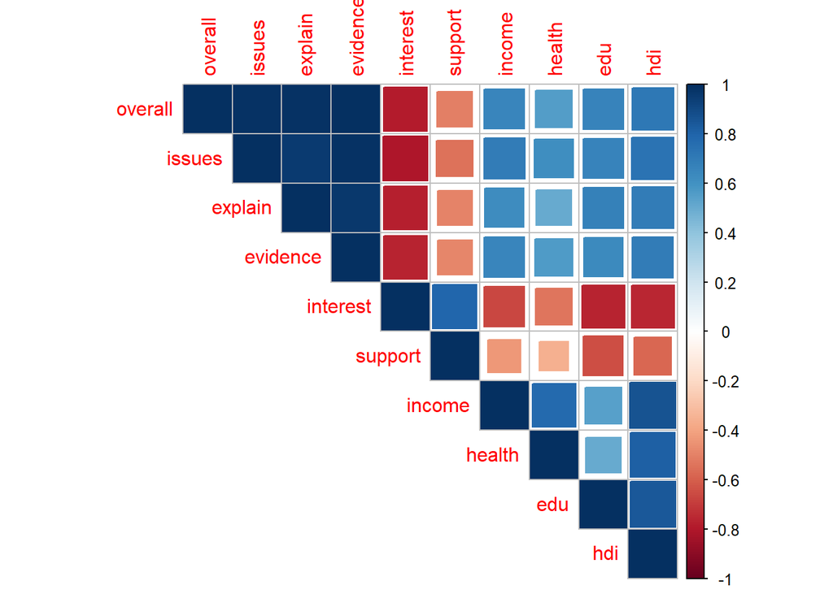

```r
eliminamos_factor <- c("country")
# Correlaciones

corrplot(cor(data_pisa%>%
               select_at(vars(-eliminamos_factor)),
             use = "complete.obs"),
         method = "square",type = "upper")
```

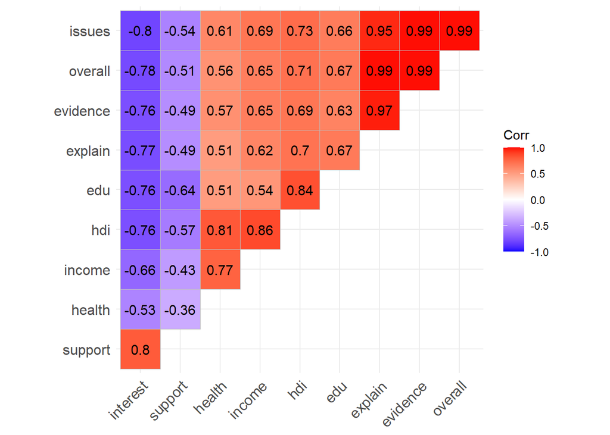

```r
# Other Correlations
ggcorrplot(cor(data_pisa %>%
               select_at(vars(-eliminamos_factor)),
            use = "complete.obs"),
            hc.order = TRUE,
            type = "upper",  lab = TRUE)
```

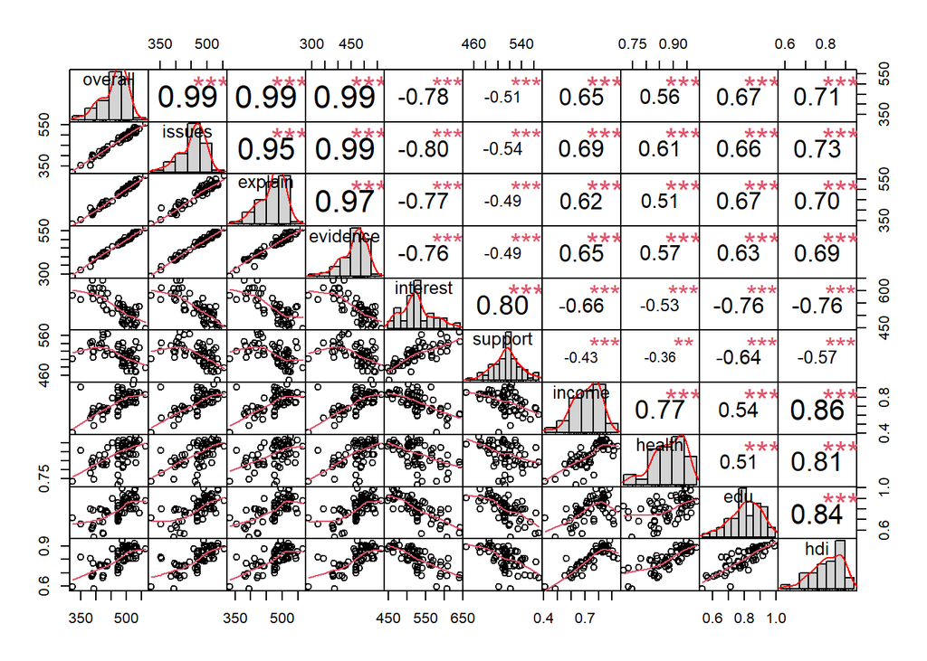

```r
chart.Correlation(data_pisa%>%
                  select_at(vars(-eliminamos_factor)),
               histogram=TRUE, pch=19)
```

Grados de libertad , esta formula adecua de manera automatica la curva a los datos

```r
sp_interest <- smooth.spline(data_pisa$interest, data_pisa$overall, cv=TRUE)
sp_interest
```

```
## Call:
## smooth.spline(x = data_pisa$interest, y = data_pisa$overall,
##     cv = TRUE)
##
## Smoothing Parameter  spar= 0.9311547  lambda= 0.00465548 (13 iterations)
## Equivalent Degrees of Freedom (Df): 4.750171
## Penalized Criterion (RSS): 49516.15
## PRESS(l.o.o. CV): 916.1849
```

```r
sp_support <- smooth.spline(data_pisa$support, data_pisa$overall, cv=TRUE)
sp_support
```

```
## Call:
## smooth.spline(x = data_pisa$support, y = data_pisa$overall, cv = TRUE)
##
## Smoothing Parameter  spar= 1.499961  lambda= 81.82485 (28 iterations)
## Equivalent Degrees of Freedom (Df): 2.001243
## Penalized Criterion (RSS): 68396.87
## PRESS(l.o.o. CV): 1996.088
```

```r
sp_income <- smooth.spline(data_pisa$income, data_pisa$overall, cv=TRUE)
sp_income
```

```
## Call:
## smooth.spline(x = data_pisa$income, y = data_pisa$overall, cv = TRUE)
##
## Smoothing Parameter  spar= 1.080197  lambda= 0.007177517 (14 iterations)
## Equivalent Degrees of Freedom (Df): 4.244952
## Penalized Criterion (RSS): 66984.17
## PRESS(l.o.o. CV): 1293.909
```

```r
sp_Health<- smooth.spline(data_pisa$health, data_pisa$overall ,cv=TRUE)
sp_Health
```

```
## Call:
## smooth.spline(x = data_pisa$health, y = data_pisa$overall, cv = TRUE)
##
## Smoothing Parameter  spar= 1.499962  lambda= 44.19162 (28 iterations)
## Equivalent Degrees of Freedom (Df): 2.002844
## Penalized Criterion (RSS): 101821
## PRESS(l.o.o. CV): 1913.591
```

```r
sp_edu <- smooth.spline(data_pisa$edu, data_pisa$overall ,cv=TRUE)
sp_edu
```

```
## Call:
## smooth.spline(x = data_pisa$edu, y = data_pisa$overall, cv = TRUE)
##
## Smoothing Parameter  spar= 1.49996  lambda= 52.19016 (28 iterations)
## Equivalent Degrees of Freedom (Df): 2.002385
## Penalized Criterion (RSS): 75381.88
## PRESS(l.o.o. CV): 1505.755
```

```r
sp_hdi <- smooth.spline(data_pisa$hdi, data_pisa$overall ,cv=TRUE)
sp_hdi
```

```
## Call:
## smooth.spline(x = data_pisa$hdi, y = data_pisa$overall, cv = TRUE)
##
## Smoothing Parameter  spar= 0.7604012  lambda= 0.0002060338 (11 iterations)
## Equivalent Degrees of Freedom (Df): 8.603228
## Penalized Criterion (RSS): 50163.52
## PRESS(l.o.o. CV): 1520.306
```

Un ploteo a modo de comparacion

El grafo amarillo indica una modelacion con un criterio mio insertando un numero random, el azul, sin embargo, nos ajusta automaticamente el modelo suavizado a un optimo que regulariza el modelo, no ajusta de manera tan precisa pero cubre posibles predicciones futuras sin ajustarse tanto al dato. no buscamos un criterio de explicativo optimo, buscamos un criterio predictivo optimo.

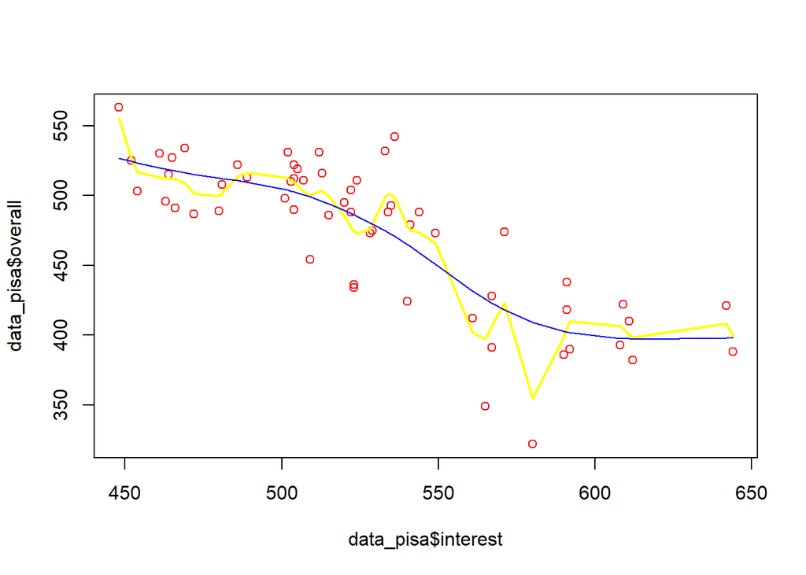

```r
plot(data_pisa$interest, data_pisa$overall, col='red')
criterio_aleat <- smooth.spline(data_pisa$interest, data_pisa$overall, df=19)
criterio_smooth <- smooth.spline(data_pisa$interest, data_pisa$overall, cv=TRUE)
lines(criterio_aleat, col='yellow', lwd=2)
lines(criterio_smooth, col='blue', lwd=1)
```

# MODELOS GAM

GAM1

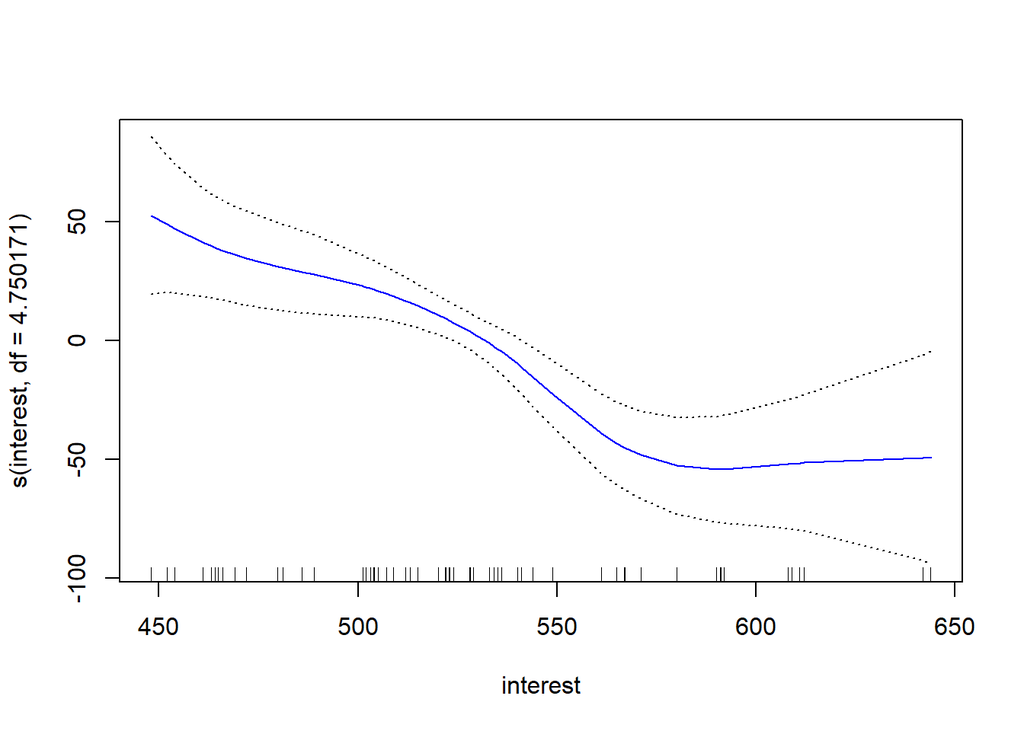

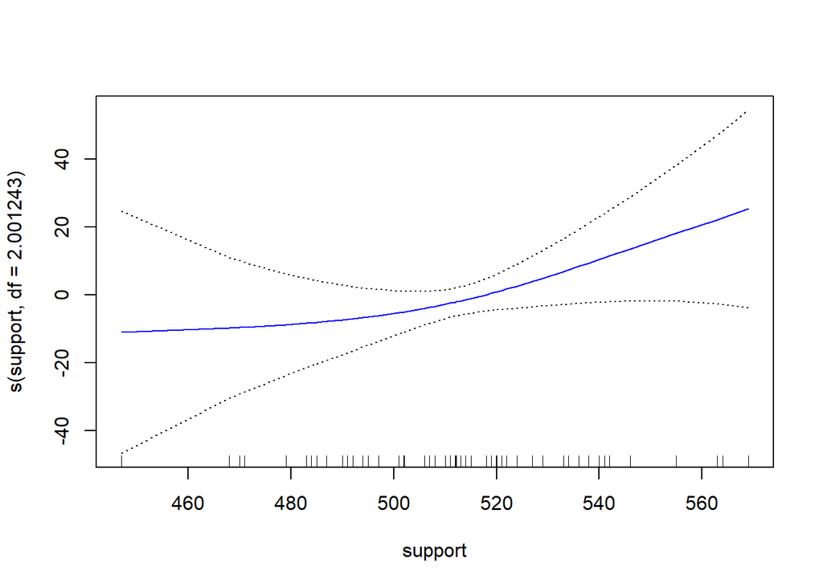

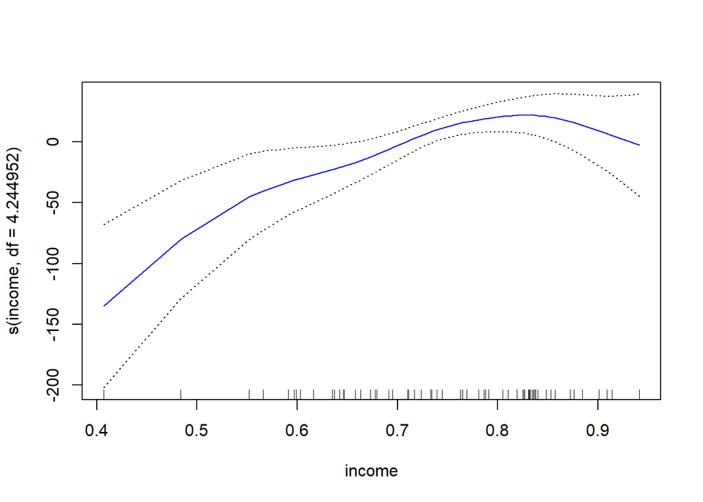

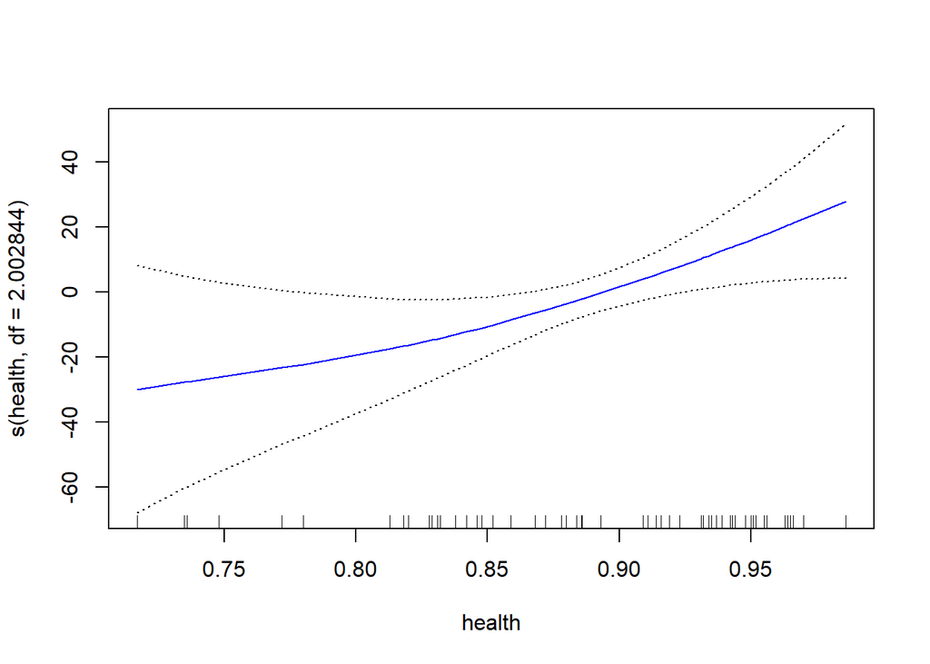

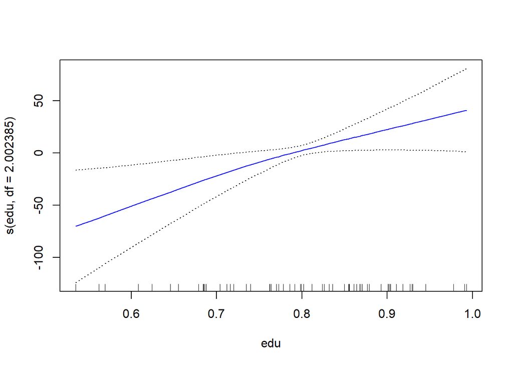

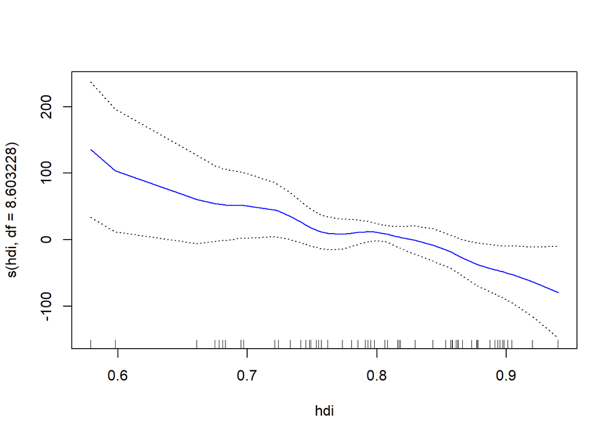

```r
gam1 <- gam(overall ~ s(interest, df=4.750171) + s(support, df=2.001243) + s(income, df=4.244952)+ s(health, df=2.002844)+ s(edu, df=2.002385)+ s(hdi, df=8.603228),
            data = data_pisa )
plot(gam1, se=TRUE, col='blue')
```

```r
summary(gam1)
```

```
##
## Call: gam(formula = overall ~ s(interest, df = 4.750171) + s(support,
##     df = 2.001243) + s(income, df = 4.244952) + s(health, df = 2.002844) +
##     s(edu, df = 2.002385) + s(hdi, df = 8.603228), data = data_pisa)
## Deviance Residuals:
##     Min      1Q  Median      3Q     Max
## -60.474  -8.204   3.146  11.663  51.433
##
## (Dispersion Parameter for gaussian family taken to be 596.1798)
##
##     Null Deviance: 166828.9 on 64 degrees of freedom
## Residual Deviance: 24082.78 on 40.3952 degrees of freedom
## AIC: 620.1379
##
## Number of Local Scoring Iterations: NA
##
## Anova for Parametric Effects
##                                Df Sum Sq Mean Sq  F value   Pr(>F)
## s(interest, df = 4.750171)  1.000  90386   90386 151.6092 2.96e-15 ***
## s(support, df = 2.001243)   1.000   2922    2922   4.9011  0.03255 *
## s(income, df = 4.244952)    1.000   4153    4153   6.9665  0.01174 *
## s(health, df = 2.002844)    1.000    743     743   1.2458  0.27095
## s(edu, df = 2.002385)       1.000    341     341   0.5713  0.45413
## s(hdi, df = 8.603228)       1.000   3326    3326   5.5795  0.02308 *
## Residuals                  40.395  24083     596
## ---
## Signif. codes:  0 '***' 0.001 '**' 0.01 '*' 0.05 '.' 0.1 ' ' 1
##
## Anova for Nonparametric Effects
##                            Npar Df Npar F   Pr(F)
## (Intercept)
## s(interest, df = 4.750171)     3.8 3.3651 0.02010 *
## s(support, df = 2.001243)      1.0 1.6195 0.21046
## s(income, df = 4.244952)       3.2 6.2325 0.00109 **
## s(health, df = 2.002844)       1.0 1.4044 0.24301
## s(edu, df = 2.002385)          1.0 1.7024 0.19939
## s(hdi, df = 8.603228)          7.6 1.2305 0.30759
## ---
## Signif. codes:  0 '***' 0.001 '**' 0.01 '*' 0.05 '.' 0.1 ' ' 1
```

Realizare un modelo Gam2 eliminando el spline a las variables suport, health y edu que parece que se aproximan mas a un aspecto lineal, veremos que conclusiones derivamos.

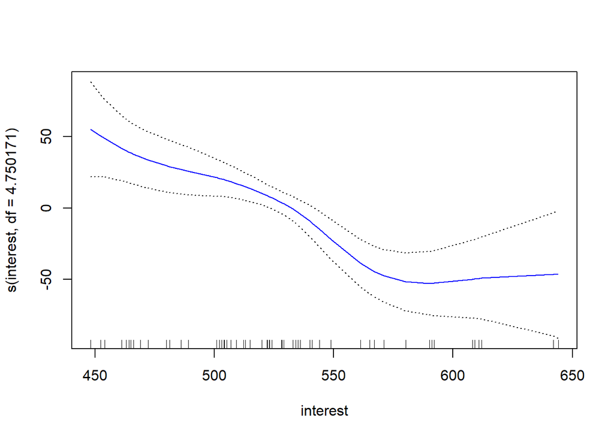

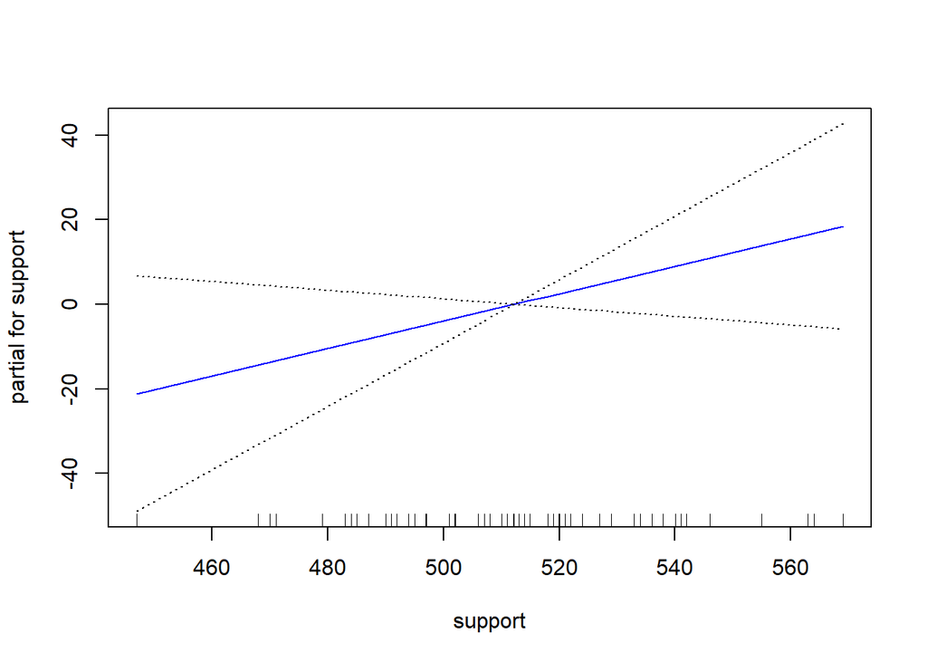

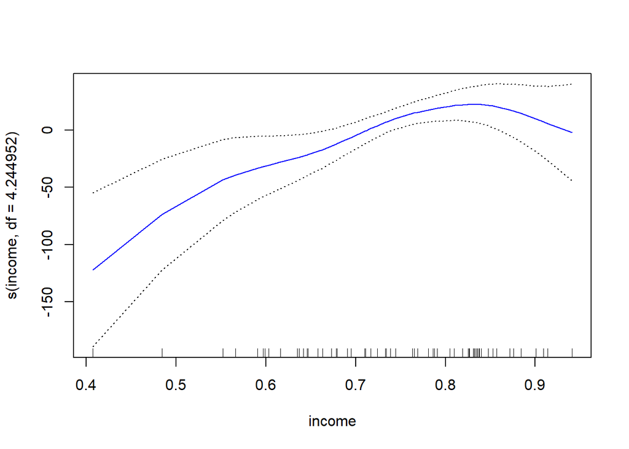

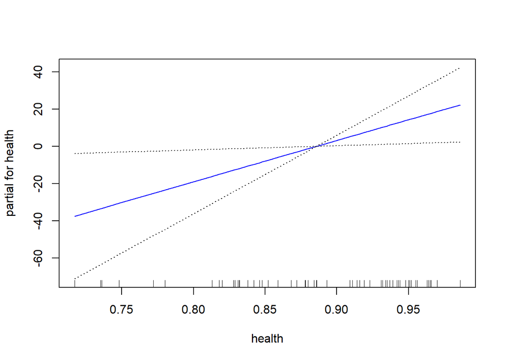

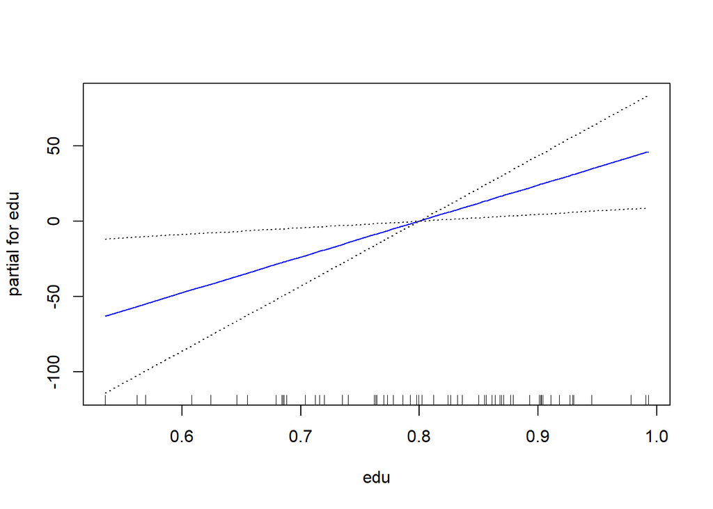

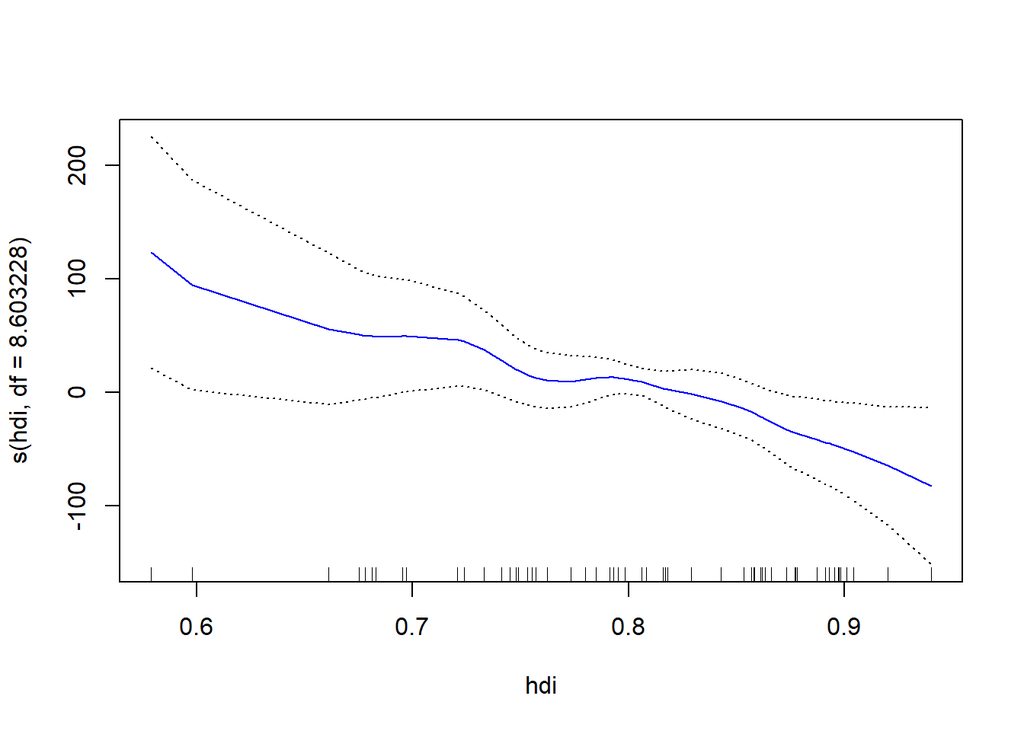

```r
gam2 <- gam(overall ~ s(interest, df=4.750171) + support + s(income, df=4.244952)+ health + edu + s(hdi, df=8.603228),
            data = data_pisa )
plot(gam2, se=TRUE, col='blue')
```

```r
summary(gam2)
```

```
##
## Call: gam(formula = overall ~ s(interest, df = 4.750171) + support +
##     s(income, df = 4.244952) + health + edu + s(hdi, df = 8.603228),
##     data = data_pisa)
## Deviance Residuals:
##     Min      1Q  Median      3Q     Max
## -64.105  -8.624   3.353  10.801  54.623
##
## (Dispersion Parameter for gaussian family taken to be 598.5364)
##
##     Null Deviance: 166828.9 on 64 degrees of freedom
## Residual Deviance: 25977.54 on 43.4018 degrees of freedom
## AIC: 619.0475
##
## Number of Local Scoring Iterations: NA
##
## Anova for Parametric Effects
##                                Df Sum Sq Mean Sq  F value    Pr(>F)
## s(interest, df = 4.750171)  1.000  91111   91111 152.2224 8.748e-16 ***
## support                     1.000   2862    2862   4.7817  0.034201 *
## s(income, df = 4.244952)    1.000   4395    4395   7.3426  0.009603 **
## health                      1.000    826     826   1.3798  0.246545
## edu                         1.000    570     570   0.9529  0.334383
## s(hdi, df = 8.603228)       1.000   3092    3092   5.1662  0.028038 *
## Residuals                  43.402  25978     599
## ---
## Signif. codes:  0 '***' 0.001 '**' 0.01 '*' 0.05 '.' 0.1 ' ' 1
##
## Anova for Nonparametric Effects
##                            Npar Df Npar F    Pr(F)
## (Intercept)
## s(interest, df = 4.750171)     3.8 3.4750 0.016844 *
## support
## s(income, df = 4.244952)       3.2 5.1134 0.003309 **
## health
## edu
## s(hdi, df = 8.603228)          7.6 1.2566 0.292136
## ---
## Signif. codes:  0 '***' 0.001 '**' 0.01 '*' 0.05 '.' 0.1 ' ' 1
```

No sacamos como significativas las variables health y edu pero conseguimos mejorar el AIC en un punto.

No creo que esta medida sea determinante porque ha mejorado minimamente.

vamos a analizar la varianza para determinar con cual de ambos nos quedamos

#Analisis de varianza (ANOVA)

```r
anova(gam1, gam2)
```

```
## Analysis of Deviance Table
##
## Model 1: overall ~ s(interest, df = 4.750171) + s(support, df = 2.001243) +
##     s(income, df = 4.244952) + s(health, df = 2.002844) + s(edu,
##     df = 2.002385) + s(hdi, df = 8.603228)
## Model 2: overall ~ s(interest, df = 4.750171) + support + s(income, df = 4.244952) +
##     health + edu + s(hdi, df = 8.603228)
##   Resid. Df Resid. Dev      Df Deviance Pr(>Chi)
## 1    40.395      24083
## 2    43.402      25978 -3.0066  -1894.8   0.3661
```

Nos quedamos con el modelo gam1 ya que es el que menor numero de residuos tiene

No realizo division de muestras para entrenamiento ni testeo ya que considero que es un espacio muy pequeño